# Beyond the Bookshelf: Family Influences on Early Language Production

Cecilia Nguyen, Kristen Gilyard, Elika Bergelson

# 1 Introduction

Early childhood is a critical period for language acquisition, shaped by a complex interplay of biological maturation and environmental input. While caregiver interaction is a well-established influence on early language outcomes, the broader family context, particularly the presence of siblings and multilingual exposure, plays a significant but complex role [@https://doi.org/10.1016/j.dr.2005.11.002], [@https://psycnet.apa.org/doi/10.2307/1130985].

The resource dilution model (RDM) posits that parental attention and cognitive resources are finite and become increasingly divided as family size grows, potentially limiting the amount and quality of linguistic input each child receives [@http://dx.doi.org/10.3389/fpsyg.2015.01874]. In bilingual households, where language exposure may already be limited or uneven across languages, siblings may act as both sources of input and competitors for these constrained linguistic resources. Supporting this, studies have shown that children from families with multiple siblings, particularly three or more, tend to have lower second language (L2) skills, especially when access to early education is limited [@https://doi.org/10.3389/fpsyg.2015.00705]. However, the effect of siblings is not unidirectional. Older siblings may act as linguistic models and provide rich communicative experiences that supplement parental input. Research suggests that the gender and age gap of siblings can also shape the quality of these interactions, with some studies indicating that older sisters contribute more positively to early language outcomes than older brothers [@https://doi.org/10.1177/0956797619861436].

Still, the findings are mixed. While some studies report a positive influence of older siblings—particularly sisters—others find minimal or even negative effects once other variables, such as parental interaction quality, are accounted for [@https://doi.org/10.1111/infa.12578]. Moreover, relatively little is known about how specific sibling identities and multilingual environments intersect to shape early vocabulary development. Few studies have incorporated detailed measures of parent-child reading behaviors, despite evidence that such interactions are closely linked to vocabulary growth and later academic achievement.

# 2 Methodology

The present study investigates whether sibling identity, household language environment, and parent-child reading engagement are associated with toddlers’ language production. Parents of 74 toddlers completed surveys about their household composition, reading behaviors, and language practices. Language production was assessed using the MacArthur-Bates Communicative Development Inventory (MB-CDI), with the Words and Sentences (WS) form used for children over 19 months and the Words and Gestures (WG) form used for children under 19 months. From these surveys, we calculated standardized production scores and derived parent and child reading behavior scores based on reported practices such as elaboration, object labeling, and child pointing. The sample included 53 children with siblings and 21 without, and 18 households reported speaking a non-English language at home. This data provides an opportunity to explore how family-level factors interact with language development during a period of rapid linguistic growth.

# 3 **Visualizations & Descriptive Stats**

## 3.1 Descriptive Tables

| Variable | Mean | SD | N |
| --- | --- | --- | --- |
| Child Age (m) | 19.118 | 4.586 | 68 |
| Child Score | 24.849 | 5.507 | 73 |
| Parent Score | 23.123 | 3.789 | 73 |
| Words Understood | 139.897 | 122.172 | 39 |
| Words Produced | 139.897 | 122.172 | 39 |
| Total Produced | 228.533 | 168.695 | 30 |

While most variables have around 70 participants, `Words Produced` and `Total Produced` have smaller N due to half the participants being WG and the other half being WS. This can lower power and increase uncertainty.

`Child Score` and `Parent Score` means were fairly close to each other, however the SDs suggest variability, indicating that some children and parents score much higher and some much lower.

`Words Produced` and `Total Produced` had a very large difference in mean and SDs, which suggest that some children were producing very few words while others were producing very many. TThis is to be expected because `Words Produced` data derived from WG, which were given to children <19 months of age, while `Total Produced` came from WS, given to children >19 months.

| Variable | Mean | SD | N |
| --- | --- | --- | --- |
| Child Age (m) | 19.020 | 4.603 | 49 |
| Child Score | 24.547 | 5.195 | 53 |
| Parent Score | 22.736 | 3.574 | 53 |
| Words Understood | 115.214 | 96.000 | 28 |
| Words Produced | 115.214 | 96.000 | 28 |
| Total Produced | 231.273 | 168.200 | 22 |

## 3.2 MBCDI Output

`Words Understood` and `Words Produced` are taken from the WG form while `Total Produced` is taken from the WS form.

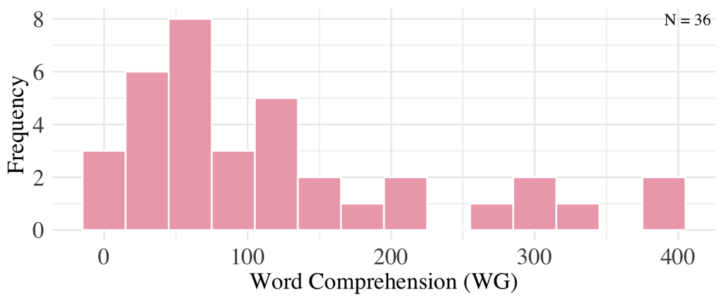

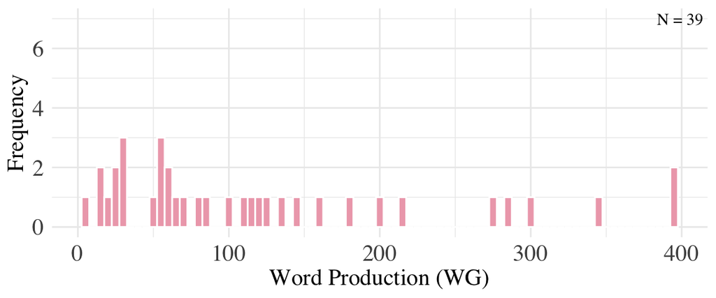

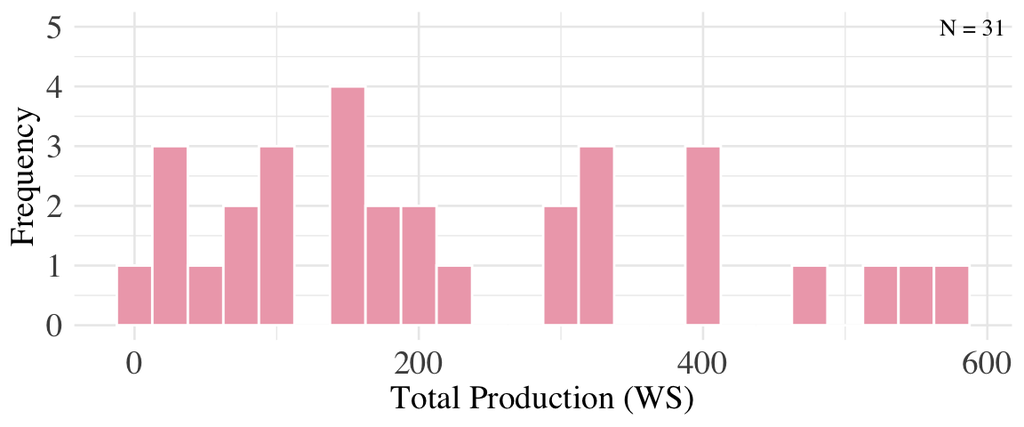

## 3.3 Age Breakdown

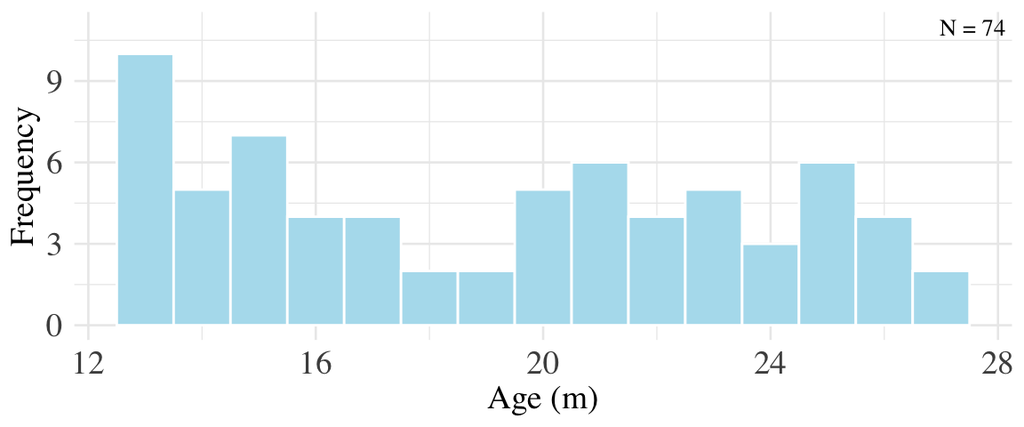

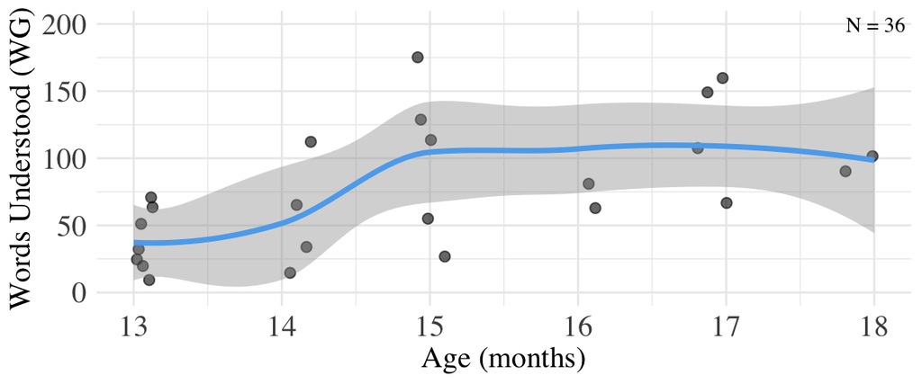

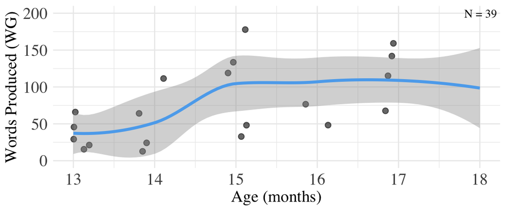

[figure not shown]

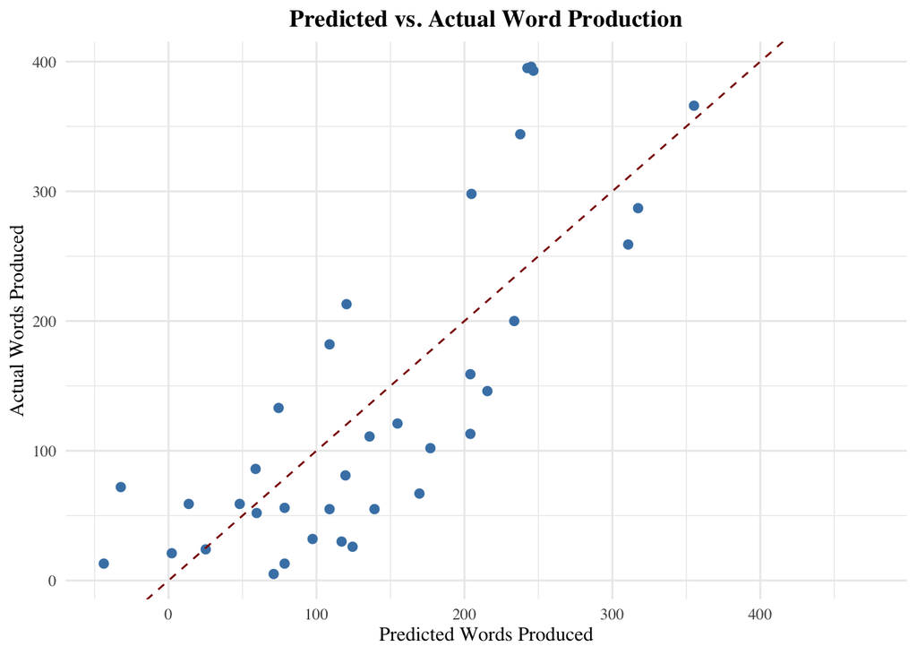

```r
model_prod_child_age <- lm(`Words Produced` ~ child_score + age, data = combined)

combined$predicted_wp <- predict(model_prod_child_age, newdata = combined)


ggplot(combined[!is.na(combined$predicted_wp), ], aes(x = predicted_wp, y = `Words Produced`)) +
  geom_point(color = "steelblue", size = 2) +
  geom_abline(slope = 1, intercept = 0, linetype = "dashed", color = "darkred") +
  labs(
    title = "Predicted vs. Actual Word Production",
    x = "Predicted Words Produced",
    y = "Actual Words Produced"
  ) +
  theme_minimal(base_family = "Times") +
  theme(plot.title = element_text(face = "bold", hjust = 0.5))
```

## 3.4 Children and Parent Scores

Survey Items Used to Compute Composite Parent and Child Scores

| Parent Score Items | Child Score Items |
| --- | --- |
| Extending beyond the text: connection to things in the book | Child repeats words from book |
| Extending beyond the text: connection to outside of the book | Child touches objects on the pages of the book |
| Labelling/naming objects | Child looks at items on the page during book-reading |
| Asking questions | Child points to objects on the page during book-reading |
| Pausing to wait for child’s response | Child vocalizes or makes sounds during book-reading |

Note: All items were noted in relation to during book-reading sessions and were rated on a 7-point Likert scale ranging from 1 (not often) to 7 (very often).

### 3.4.1 Parent Score

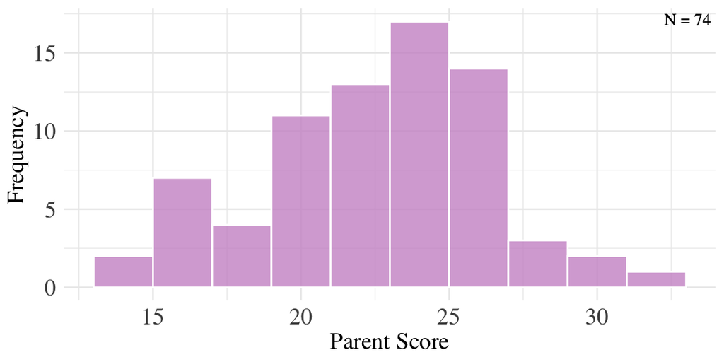

### 3.4.2 Child Score

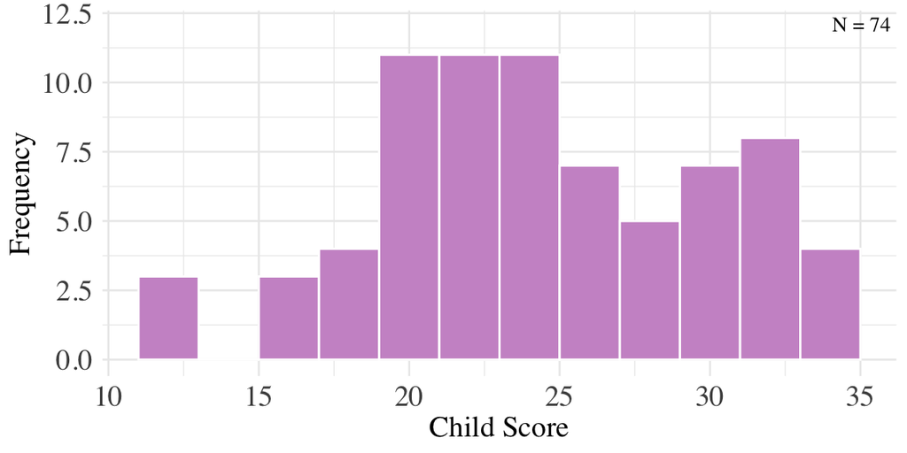

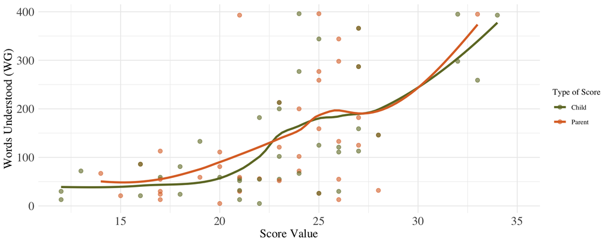

```r
combined_long <- combined %>%
  select(parent_score, child_score, `Words Understood`) %>%
  rename(
    Parent = parent_score,
    Child = child_score,
    WordProd = `Words Understood`
  ) %>%
  pivot_longer(cols = c(Parent, Child), names_to = "Score_Type", values_to = "Score")

ggplot(combined_long, aes(x = Score, y = WordProd, color = Score_Type, fill = Score_Type)) +
  geom_point(alpha = 0.6, size = 2) +  # ⬅️ Adds the dots
  geom_smooth(method = "loess", se = FALSE, size = 1.2) +
  scale_fill_manual(values = c("skyblue", "orange")) +
  scale_color_manual(values = c("#6e772d", "#dd702d")) +
  labs(
    x = "Score Value",
    y = "Words Understood (WG)",
    fill = "Score Type",
    color = "Type of Score"
  ) +
  theme_minimal(base_family = "Times") +
  theme(
    plot.title = element_text(face = "bold", hjust = 0.5)
  ) +
  guides(fill = "none") +
  custom_theme
```

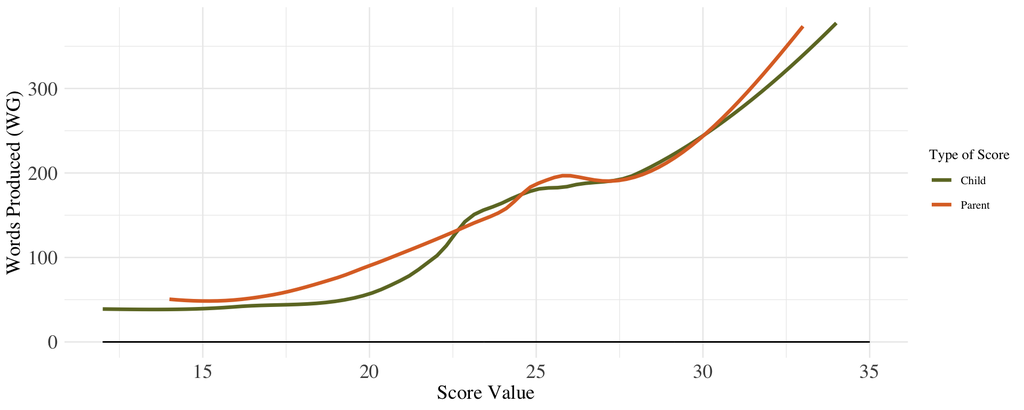

```r
combined_long <- combined %>%
  select(parent_score, child_score, `Words Produced`) %>%
  rename(
    Parent = parent_score,
    Child = child_score,
    WordProd = `Words Produced`
  ) %>%
  pivot_longer(cols = c(Parent, Child), names_to = "Score_Type", values_to = "Score")

ggplot(combined_long, aes(x = Score, fill = Score_Type)) +
  geom_density(alpha = 0.4) +
  geom_smooth(aes(y = WordProd, color = Score_Type), method = "loess", se = FALSE, size = 1.2) +
  scale_fill_manual(values = c("skyblue", "orange")) +
  scale_color_manual(values = c("#6e772d", "#dd702d")) +
  labs(
    x = "Score Value",
    y = "Words Produced (WG)",
    fill = "Score Type",
    color = "Type of Score"
  ) +
  theme_minimal(base_family = "Times") +
  theme(plot.title = element_text(face = "bold", hjust = 0.5)) + guides(fill = "none") + custom_theme
```

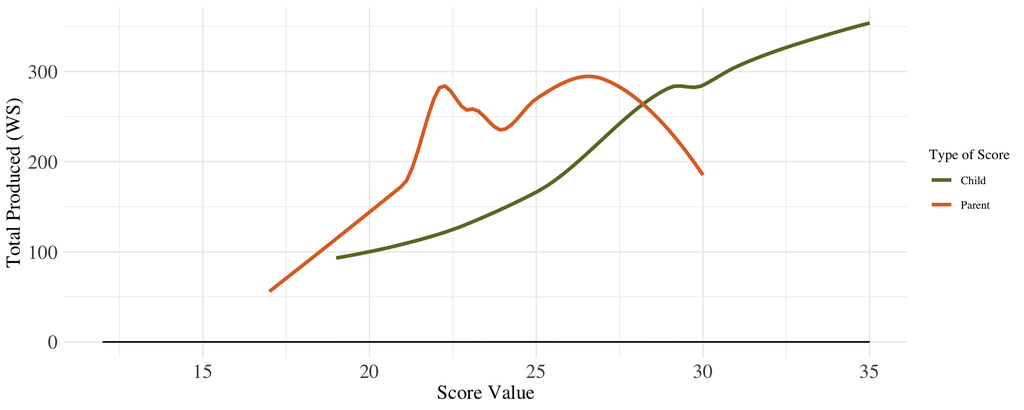

```r
combined_long <- combined %>%
  select(parent_score, child_score, `Total Produced`) %>%
  rename(
    Parent = parent_score,
    Child = child_score,
    WordProd = `Total Produced`
  ) %>%
  pivot_longer(cols = c(Parent, Child), names_to = "Score_Type", values_to = "Score")

ggplot(combined_long, aes(x = Score, fill = Score_Type)) +
  geom_density(alpha = 0.4) +
  geom_smooth(aes(y = WordProd, color = Score_Type), method = "loess", se = FALSE, size = 1.2) +
  scale_fill_manual(values = c("skyblue", "orange")) +
  scale_color_manual(values = c("#6e772d", "#dd702d")) +
  labs(
    x = "Score Value",
    y = "Total Produced (WS)",
    fill = "Score Type",
    color = "Type of Score"
  ) +
  theme_minimal(base_family = "Times") +
  theme(plot.title = element_text(face = "bold", hjust = 0.5)) + guides(fill = "none") + custom_theme
```

## Household Details

### 3.4.3 Sibling Count and Identity

After looking at the parent and child scores, the specific household details, specifically about sibling count and identity was graphed. `Sibling Identity` refers to the sibling’s relation to the target child.

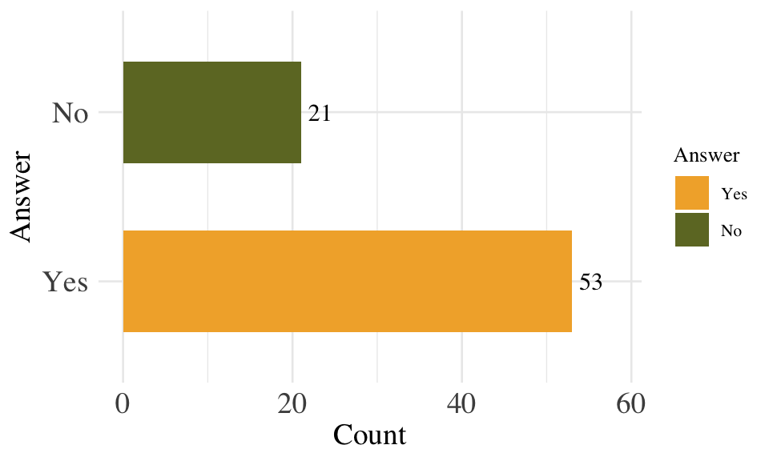

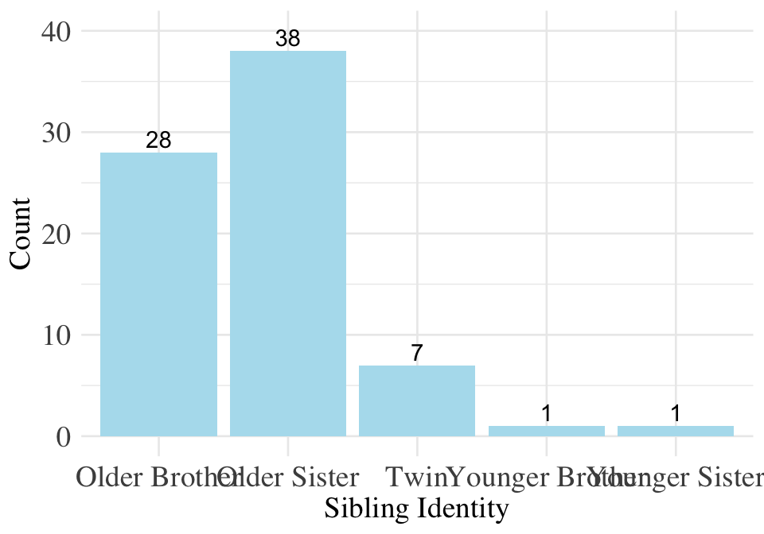

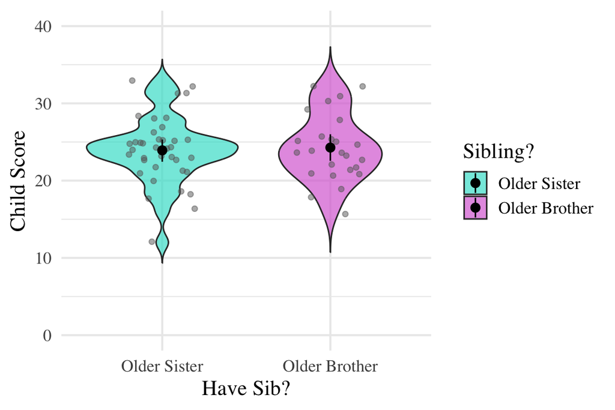

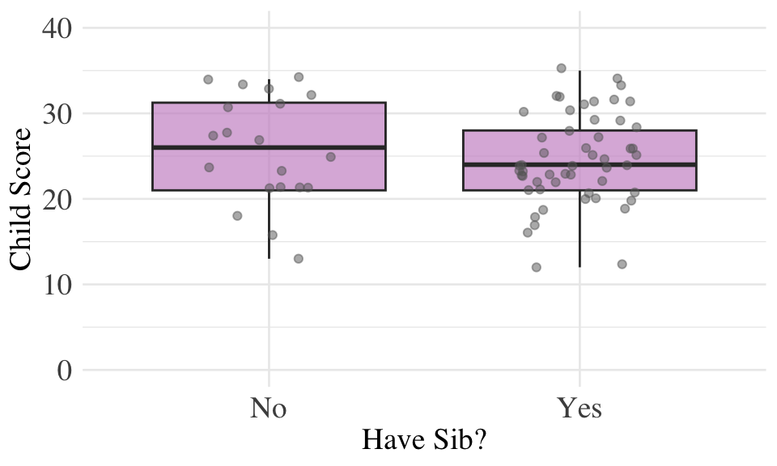

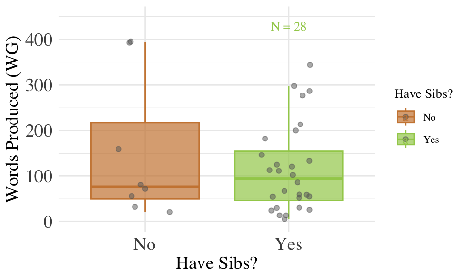

```r
sibship_factors <- sibship_factors %>% mutate(Subject_ID = as.character(Subject_ID))
combined <- combined %>% mutate(subject_id = as.character(subject_id))


sibship_factors <- sibship_factors %>%
  left_join(
    combined %>%
      select(subject_id, parent_score, child_score, `Words Produced`, `Words Understood`, `Total Produced`),
    by = c("Subject_ID" = "subject_id"))

sibship_factors$Sib_Identity <- factor(sibship_factors$Sib_Identity, levels = c("Older Sister", "Older Brother"))

ggplot(sibship_factors %>% filter(!is.na(Sib_Identity)),
       aes(x = Sib_Identity, y = child_score, fill = Sib_Identity)) +
  geom_violin(trim = FALSE, alpha = 0.7) +
  scale_fill_manual(name = "Sibling?", values = c("turquoise", "orchid")) +
  geom_jitter(width = 0.2, alpha = 0.5, color = "grey40") +
  scale_y_continuous(limits = c(0, 40)) +
  stat_summary(fun.data = "mean_cl_boot", geom = "pointrange", colour = "black") +
  labs(
    x = "Have Sib?",
    y = "Child Score"
  ) +
  theme_minimal(base_size = 15, base_family = "Times")
```

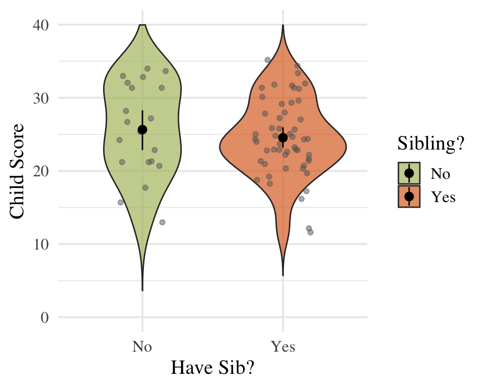

```r
combined$Sibling <- factor(combined$`Are there any other children who live in your home?`, levels = c("No", "Yes"))

child_sib_test <- wilcox.test(child_score ~ Sibling, data = combined)

ggplot(lang_df, aes(x = sib_binary, y = child_score, fill = sib_binary)) +
  geom_violin(trim = FALSE, alpha = 0.7) +
  scale_fill_manual(  name = "Sibling?", values = c("#b2bf6d", "#dd702d")) +
  geom_jitter(width = 0.2, alpha = 0.5, color = "grey40") +
  scale_y_continuous(limits = c(0, 40)) +
  stat_summary(
    fun.data = function(x) {
      data.frame(
        y = max(x, na.rm = TRUE) * 1.25,
        label = paste0("N = ", sum(!is.na(x)))
      )
    },
    geom = "text",
    size = 3.5,
    family = "Times"
  ) +
  labs(
    x = "Have Sib?",
    y = "Child Score"
  ) +
  theme_minimal(base_size = 15, base_family = "Times") +
  stat_summary(fun.data = "mean_cl_boot", geom = "pointrange",
               colour = "black")
```

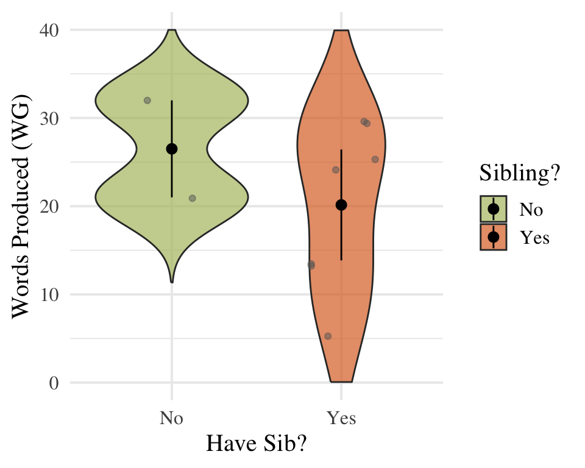

```r
combined$Sibling <- factor(combined$`Are there any other children who live in your home?`, levels = c("No", "Yes"))
combined$Sibling <- factor(combined$Sibling)
combined <- droplevels(combined)

child_sib_test <- wilcox.test(`Words Produced` ~ Sibling, data = combined)

ggplot(combined, aes(x = Sibling, y = `Words Produced`, fill = Sibling)) +
  geom_violin(trim = FALSE, alpha = 0.7) +
  scale_fill_manual(  name = "Sibling?", values = c("#b2bf6d", "#dd702d")) +
  geom_jitter(width = 0.2, alpha = 0.5, color = "grey40") +
  scale_y_continuous(limits = c(0, 40)) +
  stat_summary(
    fun.data = function(x) {
      data.frame(
        y = max(x, na.rm = TRUE) * 1.25,
        label = paste0("N = ", sum(!is.na(x))) * 1.25
      )
    },
    geom = "text",
    size = 3.5,
    family = "Times"
  ) +
  labs(
    x = "Have Sib?",
    y = "Words Produced (WG)"
  ) +
  theme_minimal(base_size = 15, base_family = "Times") +
  stat_summary(fun.data = "mean_cl_boot", geom = "pointrange",
               colour = "black")
```

### 3.4.4 Multilingual Household

Multilingual households were also looked at. Out of 65 families, only 18 have another language, that is not English, spoken at home. The responses were also categorized by language group. `Multilingual` refers to households that speak more than one language as to not double count subjects.

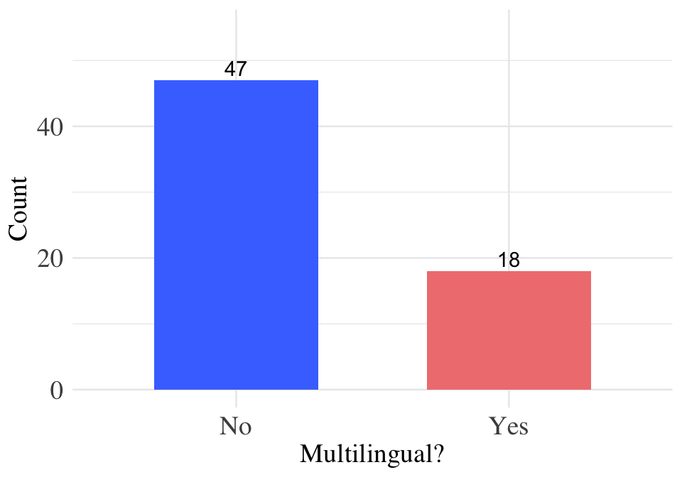

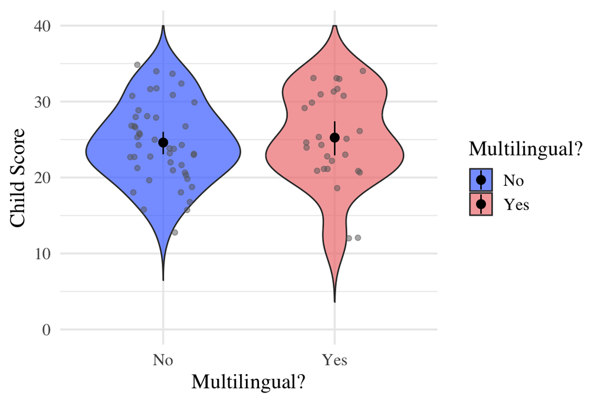

```r
combined$Sibling <- factor(combined$`Are there any other children who live in your home?`, levels = c("No", "Yes"))


ggplot(lang_df, aes(x = lang_binary, y = child_score, fill = lang_binary)) +
  geom_violin(trim = FALSE, alpha = 0.7) +
  scale_fill_manual(  name = "Multilingual?", values = c("royalblue1", "lightcoral")) +
  geom_jitter(width = 0.2, alpha = 0.5, color = "grey40") +
  scale_y_continuous(limits = c(0, 40)) +
  stat_summary(
    fun.data = function(x) {
      data.frame(
        y = max(x, na.rm = TRUE) * 1.25,
        label = paste0("N = ", sum(!is.na(x)))
      )
    },
    geom = "text",
    size = 3.5,
    family = "Times"
  ) +
  labs(
    x = "Multilingual?",
    y = "Child Score"
  ) +
  theme_minimal(base_size = 15, base_family = "Times") +
  stat_summary(fun.data = "mean_cl_boot", geom = "pointrange",
               colour = "black")
```

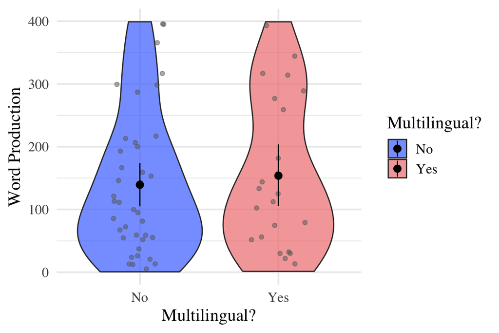

| Language | N |
| --- | --- |
| Spanish | 5 |
| Multilingual | 4 |
| Arabic | 1 |
| Cantonese | 1 |
| Farsi | 1 |
| Hebrew | 1 |
| Korean | 1 |
| Malayalam | 1 |
| Mandarin Chinese | 1 |
| Russian | 1 |
| Urdu | 1 |

```r
ggplot(lang_df, aes(x = lang_binary, y = `Produced`, fill = lang_binary)) +
  geom_violin(trim = FALSE, alpha = 0.7) +
  scale_fill_manual(  name = "Multilingual?", values = c("royalblue1", "lightcoral")) +
  geom_jitter(width = 0.2, alpha = 0.5, color = "grey40") +
  scale_y_continuous(limits = c(0, 400)) +
  stat_summary(
    fun.data = function(x) {
      data.frame(
        y = max(x, na.rm = TRUE) * 1.25,
        label = paste0("N = ", sum(!is.na(x)))
      )
    },
    geom = "text",
    size = 3.5,
    family = "Times"
  ) +
  labs(
    x = "Multilingual?",
    y = "Word Production"
  ) +
  theme_minimal(base_size = 15, base_family = "Times") +
  stat_summary(fun.data = "mean_cl_boot", geom = "pointrange",
               colour = "black")
```

# 4 Comprehension & Production, Correlation, and Parent/Child Score by Sibling Identity

Due to the low observations in the younger siblings identity, it was taken out of visualizations and analysis. There were also twins in the data, however, because twins are likely to experience highly similar environments and interactions, their inclusion could violate assumptions of data independence, their data was excluded. This was to ensure each data point reflected a unique household dynamic, twin data were excluded from comparative analyses.

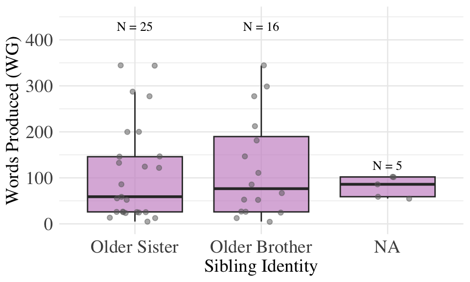

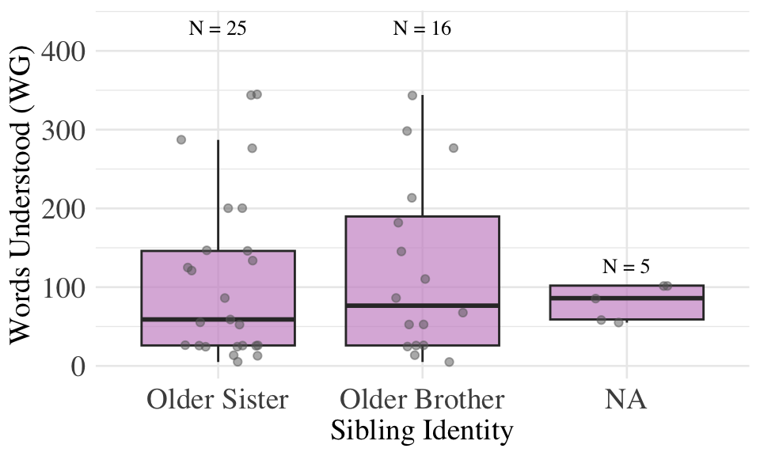

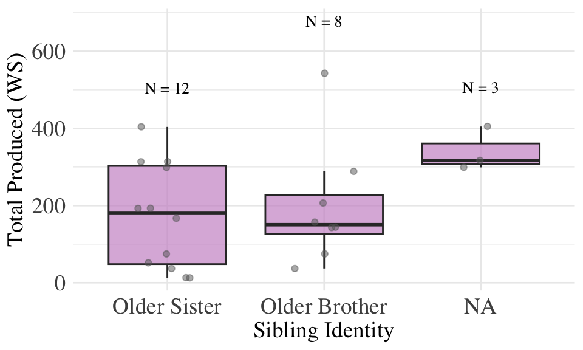

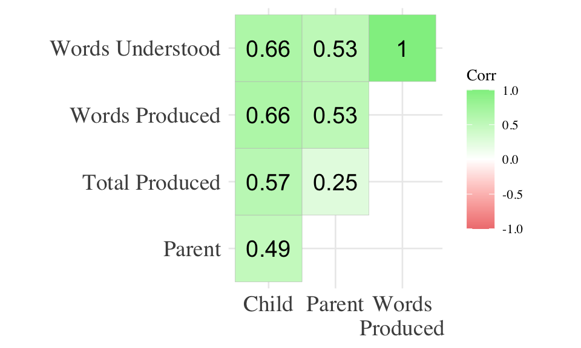

| Predictor | Outcome | Spearman's ρ | p-value |
| --- | --- | --- | --- |
| Words Produced | Child Score | 0.654 | < .001 |
| Words Understood | Child Score | 0.654 | < .001 |
| Total Produced | Child Score | 0.517 | 0.003 |
| Words Produced | Parent Score | 0.504 | 0.001 |
| Words Understood | Parent Score | 0.504 | 0.001 |
| Total Produced | Parent Score | 0.265 | 0.150 |

Spearman correlation analyses revealed significant positive relationships between children’s language production and comprehension and their overall scores. Specifically, both the number of words produced and understood by children were strongly correlated with their Child Score (ρ = 0.654, p < .001), suggesting that children who produced or understood more words tended to score higher. A moderate positive correlation was also found between Total Produced and Child Score (ρ = 0.517, p = .003). Parent Scores showed moderate, significant correlations with children’s Words Produced and Words Understood (ρ = 0.504, p = .001 for both), indicating some alignment between children’s language abilities and parent-reported scores. However, the correlation between Total Produced and Parent Score was weaker and not statistically significant (ρ = 0.265, p = .150), suggesting limited predictive value of this measure for parent outcomes.

# 5 Comparing Sibling Identities

| Outcome | W.Statistic | p.value |
| --- | --- | --- |
| Words Understood | 203.0 | 0.130 |
| Words Produced | 203.0 | 0.130 |
| Total Produced | 95.5 | 0.896 |

To examine whether language outcomes differed based on sibling presence, Wilcoxon rank-sum tests were conducted comparing children with and without siblings across three outcome variables.

None of the comparisons reached statistical significance. These results suggest that the presence of siblings in the household was not significantly related to vocabulary comprehension or production. This analysis supports the need to consider more nuanced sibling factors, such as sibling identity (e.g., older vs. younger) or birth order, in understanding early language variation.

ANOVA: Older Siblings and Language Production

| Group | Df | Sum Sq | Mean Sq | F value | p-value |
| --- | --- | --- | --- | --- | --- |
| Sibling Identity | 1 | 749.51 | 749.51 | 0.06 | 0.8 |
| Residuals | 39 | 462365.51 | 11855.53 |  |  |

To further explore whether specific sibling identities are associated with differences in language production, a one-way ANOVA was conducted. Due to the low N values, the ANOVA only examined whether language production differed between toddlers with an older brother and those with an older sister. Results revealed no significant effect of sibling identity on words understood, F(1, 39) = 0.06, p = .80. This suggests that, within the subset of children with older siblings, whether the sibling was a brother or sister was not associated with differences in early language comprehension. However, these results should be interpreted with caution due to the relatively small sample size, which may limit statistical power and the ability to detect subtle effects.

# 6 Analysis by Language

Curious to see if there were differences in language outcome if the household was multilingual.

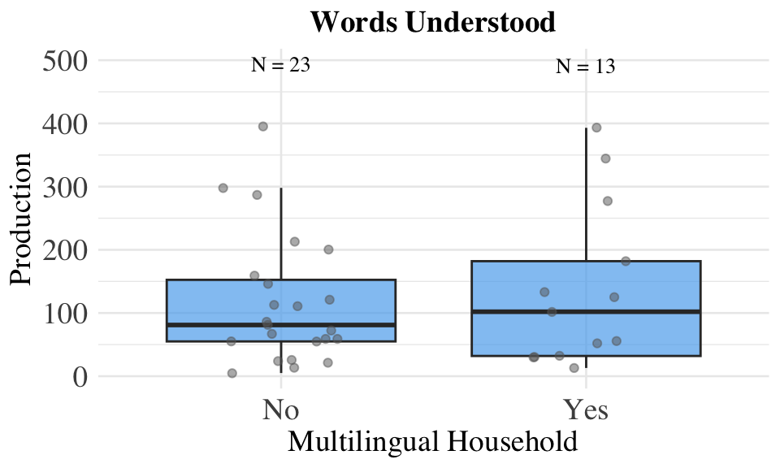

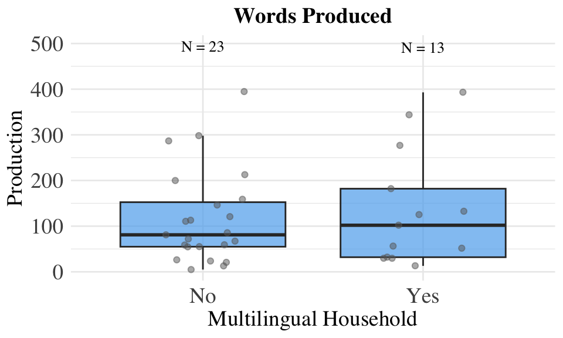

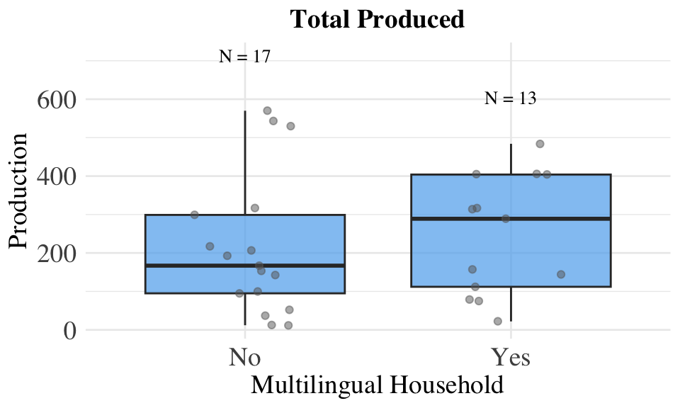

| Outcome | W.Statistic | p.value |
| --- | --- | --- |
| Words Understood | 173.5 | 0.977 |
| Words Produced | 173.5 | 0.977 |
| Total Produced | 95.5 | 0.544 |

To examine whether language outcomes differed based on additional language presence within households, Wilcoxon rank-sum tests were conducted comparing children in monolingual and multilingual households across three outcome variables.

None of the comparisons reached statistical significance. These results suggest that the presence of an additional language in the household was not significantly related to vocabulary comprehension or production. However, these results should be interpreted with caution due to the relatively small sample size, which may limit statistical power and the ability to detect subtle effects.

# 7 Reading Beliefs, Other Habits, and The In-Between

In addition to the primary parent and child reading measures, we collected exploratory items to capture broader household dynamics that may influence early language development. These items were not used in calculating the main outcome scores but were designed to provide supplementary insight into the child’s daily environment. Questions asked were answered using a Likert Scale 1 (don’t agree) to 7 (fully agree).

## 7.1 Reading Sessions

### 7.1.1 Reading Session Duration

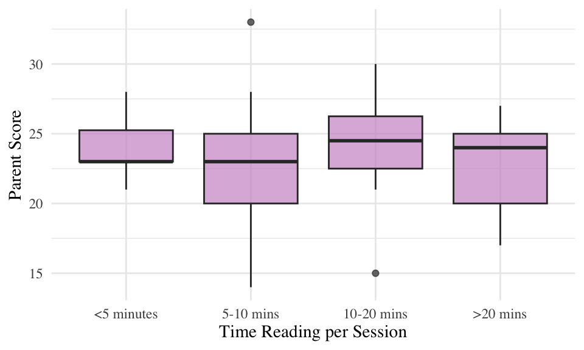

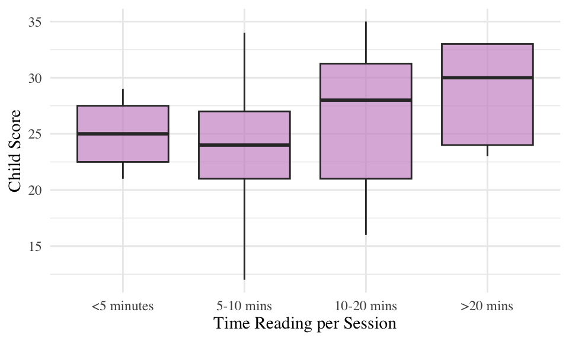

| Outcome | W.Statistic | p.value |
| --- | --- | --- |
| Parent Score | 62204.5 | 0.505 |
| Child Score | 53312.4 | 0.072 |

Ordinal Regression Coefficients

| Term | Estimate (β) | Std. Error | t value | CI Low | CI High | p-value |  |
| --- | --- | --- | --- | --- | --- | --- | --- |
| Child Score | 0.0943 | 0.0491 | 1.9202 | -0.0007 | 0.1928 | 0.0548 | . |
| Parent Score | -0.0334 | 0.0715 | -0.4666 | -0.1751 | 0.1071 | 0.6408 |  |

We used an ordinal logistic regression to examine whether parent or child scores predicted longer durations of reading sessions. The dependent variable (reading_time) was treated as an ordered factor with four categories ranging from “<5 minutes” to “>20 minutes”.

### 7.1.2 Reading Session Beliefs

Reading Purpose Ratings by Sibling Presence

| Sibling? | Mean (Edu) | SD (Edu) | Mean (Social) | SD (Social) | N |
| --- | --- | --- | --- | --- | --- |
| No | 6.33 | 1.24 | 6.62 | 0.59 | 21 |
| Yes | 5.13 | 1.64 | 6.21 | 1.04 | 53 |

```
##
## **Educational Purpose**: W = 814, p = 0.0014
```

```
##
##
## **Social Purpose**: W = 671, p = 0.1277
```

Parents in single-child households reported higher agreement with both educational and social purposes for shared reading compared to those in multi-child households. Specifically, parents without other children rated educational purpose significantly higher (M = 6.33, SD = 1.24) than parents with multiple children (M = 5.13, SD = 1.64). Although both groups rated reading as a social bonding activity highly, parents of only children again reported slightly higher agreement (M = 6.62, SD = 0.59) compared to those with siblings (M = 6.21, SD = 1.04). These findings suggest that while reading remains an important bonding experience across households, parents of only children may place greater emphasis on its educational value. This pattern aligns with the resource dilution model, which posits that the presence of siblings may reduce the time and cognitive resources available for each child, particularly for academically focused activities.

Wilcoxon and Mann–Whitney Test Results

| Test | Statistic | p-value |
| --- | --- | --- |
| Edu. Purpose by Sib Status | 814.0 | 0.00136 |
| Social Purpose by Sib Status | 671.0 | 0.12775 |
| Edu. vs Social Purpose (Paired) | 83.5 | < 0.001 |

We used non-parametric tests to explore how parents’ reading purpose ratings differed by sibling presence and purpose type. Parents of only children rated reading for educational purposes significantly higher than parents with multiple children (W = 814, p = .0014). In contrast, there was no significant difference between the two groups in how they rated reading for social bonding (W = 671, p = .1278), suggesting that the social purpose of reading is valued similarly regardless of family size.

We also compared the two purposes within the same parents. A Wilcoxon signed-rank test showed that parents overall rated social bonding as a significantly stronger reason for reading than educational learning (V = 83.5, p < .001). Together, these results suggest that while parents see reading as both educational and social, those with only children may focus more on the learning aspect, possibly because they have more time or attention to give. This aligns with the Resource Dilution Model.